# UPXome RNA-seq Notebook

Jory Curry

12 September 2022

## Notes

### QIASeq UPXome RNA Library Manual Notes

- Inclusion of QIAseq FastSelect in the workflow enables rapid and efficient removal of ribosomal RNA (rRNA) during the preparation of the NGS RNA library – increases the number of usable reads during sequencing
- Library Indexes (Unique dual-index) are 10-bases long

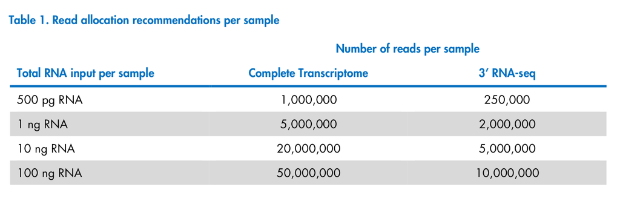

Recommended reads per sample

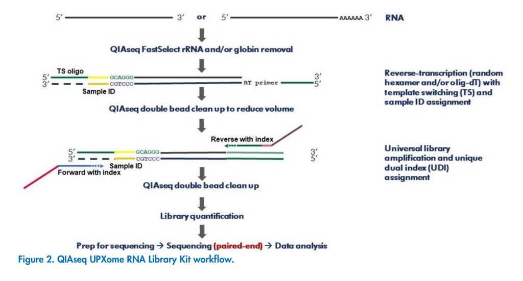

Library Workflow

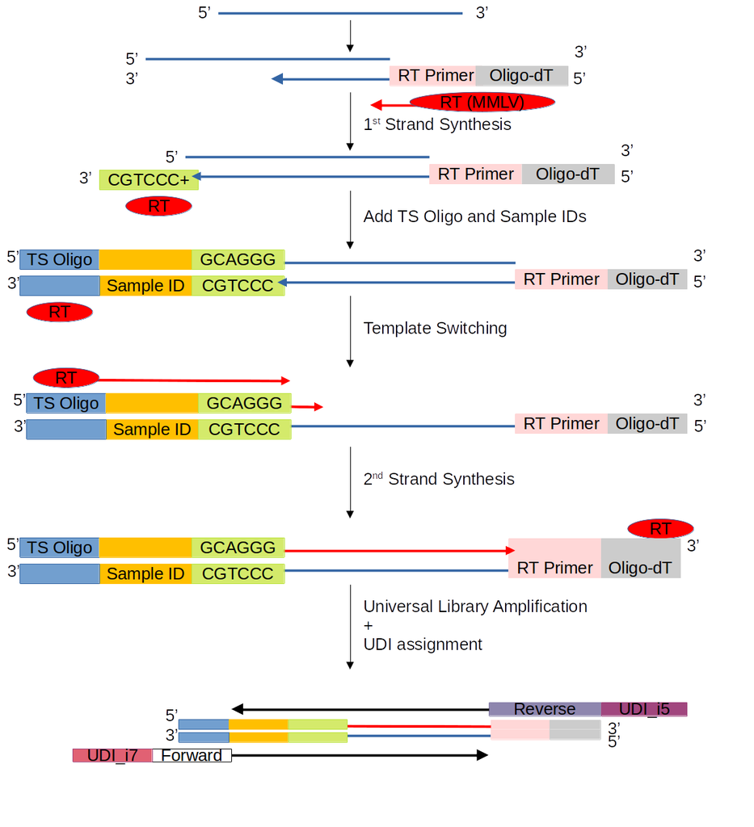

Library Structure

- Sam provided this description of what the library structure looks like (before adapter trimming):
  - CTACACGACGCTCTTCCGATCT[22bp]–[Insert]–CCCTGC[6bp]–[10bpID]–AGATCGGAAGAGCACACGTCTG[22bp]

Our Sequences had a per-base sequence-read structure as follows:

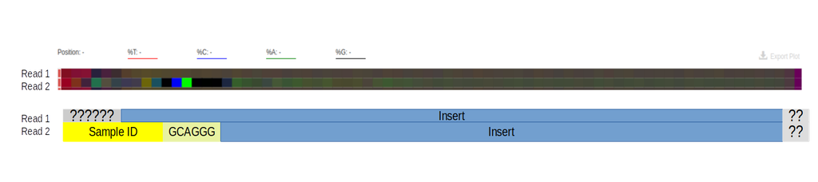

Read structure

Note: The fastq files we have, are already demultiplexed into their respective pools by UDI… The UDIs are contained in the headers of the fastq files (I will prove this later in the notebook). The sample IDs are still contained in the Read2s for each set of paired-end fastq files.

Therefore, the reads can be demultiplexed further by Sample_ID

### Digging deeper into the results

```bash
tail -8 ~/MastersBackup/Data/Qiaseq_UPXome_Whole_transcriptome_results/Extracted_Fastq_Files/Pool-ID-1_S1_L001_R1_001.fastq
```

```
## @NB551563:319:HK5NYBGXL:1:23312:18089:20399 1:N:0:NGAACGTTGT+AGTCGGCCAT
## GTCCACACAAACAGACACAGGGATATAGGCAGGCACAGACAGAGAGGATTGTGGGATACCTTGCTTTGTTAC
## +
## AAAAAEEEEEEEEEEEEEEEEEEEEEEEEEEEEEEEEEEEEEAEEEEEEEEEEEEEEEEEEEEEE/EEEEEE
## @NB551563:319:HK5NYBGXL:1:23312:22065:20399 1:N:0:NGAACGTTGT+AGTCGGCCAT
## TTTGGAGTTCTTTCTGTTTTTGGATGTACATCTTCTTAAACGTCAGGTAGTTGCCCCTGTAGTAGTAGAGTTTC
## +
## AAAAAEEAEEEAEEEEEEEEEEEEAEEEEEEEEEEEEEEEE/EEEE/EEAEEE6EEEEEEEEEEEEEEEEEEEE
```

```r
nchar("TTTGGAGTTCTTTCTGTTTTTGGATGTACATCTTCTTAAACGTCAGGTAGTTGCCCCTGTAGTAGTAGAGTTTC")
```

```
## [1] 74
```

```bash
tail -8 ~/MastersBackup/Data/Qiaseq_UPXome_Whole_transcriptome_results/Extracted_Fastq_Files/Pool-ID-1_S1_L001_R2_001.fastq
```

```
## @NB551563:319:HK5NYBGXL:1:23312:18089:20399 2:N:0:NGAACGTTGT+AGTCGGCCAT
## NNAGTGATCGGCAGGGGCTTGTCAGAGAATCAGTCTCTTTTGCGTATGCCTCCATGGAGCAACTTGTGGTTGGC
## +
## ##AAAEAEEEEEAEEEEEEEEEEEEEEAEEEEEAEEEAEEEEEEEEEEEEEEEEEEEEEEEEEEEEEEEEAEEE
## @NB551563:319:HK5NYBGXL:1:23312:22065:20399 2:N:0:NGAACGTTGT+AGTCGGCCAT
## NNACCTTATTGCAGGGGGAGCCGCAGCAGCTGAGGCTAAAGCTCGTAGGATCTTGGCTGGTCTTTCTTTCACTC
## +
## ##AAAEEEAEEEAEEEEEEEEEEEEEEEEEEEEEEEEEEEEEEEEEEEEEEEEAAEEEEEEEE<EE6EEEEEEE
```

```r
nchar("NNAGTGATCGGCAGGGGCTTGTCAGAGAATCAGTCTCTTTTGCGTATGCCTCCATGGAGCAACTTGTGGTTGGC")
```

```
## [1] 74
```

We can see that the reads are 74 bases in length You can also see in the header of the fastq files that the Unique Dual Indexes are included in the sample headers (Library Index or UDI - UDI i7 + UDI i5 Reverse complement). The first ten bases in the Read2 files are the Sample_IDs, followed by the hexamer ‘GCAGGG’. The hexamer is leftover from the template switching mechanism during the RT reaction. Therefore, we should be able to de-multiplex the fastq files into reads based off of what sample id they came from. The files are already demultiplexed by theur UDIs (They came in different folders depending on what Pool they came from)

### QC of fastq files with Bioconductor and CLI tools

#### Preliminary QC of barcode structure

We must demultiplex the data based off of their sample ID in the first 10bps of the READ2 file

Let’s first check that the UDI barcodes for identifying Pools are appropriately selected… I will use the [`barcode`](https://barcode.readthedocs.io/en/latest/introduction.html) CLI tool to compare the observed barcodes to the barcodes listed on Qiagen’s website from the [QIAseq DIRECT UDI Set 12](https://www.qiagen.com/us/products/discovery-and-translational-research/next-generation-sequencing/rna-sequencing/mirna-small-rnaseq/qiaseq-mirna-ngs/) kit

From the introduction of the tool documentation:

“Barcodes are used in NGS to tag samples before pooling. After sequencing, these barcodes are used to demultiplex the data, thereby assigning the reads to the originating sample.

The key aspect of a good set of barcodes is robustness against read errors. One read error should not be able to transform one barcode into another. This requirement can be met by selecting barcodes in such a way that the edit distance between any pair of barcodes is larger than one. An additional desired property is the ability to correct read errors. This can be done by increasing the minimal edit distance between barcodes to at least three. If one read error occurs, the sequenced barcode will have a distance of one to the original barcode and a minimum distance of two to any of the other barcodes. If the read error is high, the minimum edit distance should be increased to a higher (odd) number.”

```bash
cd ~/MastersBackup/Data/Qiaseq_UPXome_Whole_transcriptome_results/Compressed_Fastq_Files
~/anaconda3/bin/barcode test -H QIAseq-UDIs.tsv
```

```
## 0 barcodes violate the distance contraint.
```

This tool tells us that none of the UDI barcodes could possibly become ambigious with a tolerance of 1 error in the base calling procedure (i.e. an N instead or A,C,G or T). This means we can be more confident that our reads have been demultiplexed by Pool_ID well enough.

```bash
cd ~/MastersBackup/Data/Qiaseq_UPXome_Whole_transcriptome_results/Compressed_Fastq_Files
~/anaconda3/bin/barcode test -H QIAseq-Sample_IDs.tsv
```

```
## 0 barcodes violate the distance contraint.
```

Now we know we have quality barcodes, so we can continue with the analysis.

#### QC of UDI Barcodes

```bash
# Enter the directory with all of the fastq files
cd ~/MastersBackup/Data/Qiaseq_UPXome_Whole_transcriptome_results/Compressed_Fastq_Files

# Use the demultiplex command to gather lists of fastq barcode headers (There should be 2 - one for each of the unique dual indexes seperated by a plus sign), default sample size is a million
for file in *.fastq.gz; do ~/anaconda3/bin/demultiplex guess -o "$file"_barcode_headers.csv -f $file; done
```

| Index | UDI_1 | UDI_2 | UDI_1_match | UDI_2_match |
| --- | --- | --- | --- | --- |
| Pool-ID-1 | TGAACGTTGT | AGTCGGCCAT | TRUE | TRUE |
| Pool-ID-10 | AAGGCCGTAG | TTACCAACAG | TRUE | TRUE |
| Pool-ID-2 | ACCAGACTTG | GTGCTCATCG | TRUE | TRUE |
| Pool-ID-3 | ACTGGCGAAC | TCGACTTATC | TRUE | TRUE |
| Pool-ID-4 | GCGTTAGGCA | CAAGGCGTGA | TRUE | TRUE |
| Pool-ID-5 | TTATCGGCCT | TTGTGTTCCT | TRUE | TRUE |
| Pool-ID-6 | GAGGTATAAG | GCCTACTGAG | TRUE | TRUE |
| Pool-ID-7 | TCAAGGATTC | CAGGCACTTC | TRUE | TRUE |
| Pool-ID-8 | CGAACCGAGA | AGGCGAGAGA | TRUE | TRUE |
| Pool-ID-9 | GAGCCAAGTT | GAAGGTGCCT | TRUE | TRUE |

Now we know that the UDIs from the Qiagen website match the UDI barcodes located int headers of each of our fastq files.

Next, I will explore the Sample_ID barcodes that are located int he Reads of the Read2 files of the sequence read files.

#### QC of Sample_ID barcodes

```bash
# Enter the directory with all of the fastq files
cd ~/MastersBackup/Data/Qiaseq_UPXome_Whole_transcriptome_results/Compressed_Fastq_Files

# Use the demultiplex command to gather a list of barcodes from the RRead2 files and later compare those to the Sample_IDs sent to us by Qiagen. I use the -r flag to tell the tool that the barcode is int he read and the -e 10 paramater to tell the tool that the barcode is the first ten bases
for file in *.fastq.gz; do ~/anaconda3/bin/demultiplex guess -r -e 10 -o "$file"_barcode_read2.csv -f $file; done
# ~/anaconda3/bin/demultiplex guess -r -e 10 -o barcode_read2.csv -f Pool-ID-1_S1_L001_R2_001.fastq.gz
```

| Sample_ID | n | Well_ID | percentage_of_reads |
| --- | --- | --- | --- |
| ATGTCTTACG | 14 | A01 | 0.0029835351 |
| ATCGTGTTCT | 9 | A02 | 0.0019179869 |
| AAGTTCGTGC | 13 | A03 | 0.0027704255 |
| CTTCAATCCT | 16 | A04 | 0.0034097545 |
| TCGATTACCA | 13 | A05 | 0.0027704255 |
| CGGTTGTAGC | 8 | A06 | 0.0017048772 |
| GTACACTCAT | 16 | A07 | 0.0034097545 |
| TCGCGTGGTA | 16 | A08 | 0.0034097545 |
| CGGTTCAGTG | 16 | A09 | 0.0034097545 |
| GCTATGAATC | 10 | A10 | 0.0021310965 |

[output cut: 9990 more lines]

| Well_ID | UDI_1 | UDI_2 | Sample_ID |
| --- | --- | --- | --- |
| H07 | ATATACCGGT | CACGCAAGAT | GAGTAAGGAG |
| H09 | AACCGCAAGG | CGCCATTCTG | CTAGTGCTTA |
| H11 | TAGAGTTGGA | TCATATCGTC | CATTGACTCT |
| H12 | TCTTCAGAGA | CGTCACGTAG | CTGTGGACAC |

```
## [1] 0.2233389
```

```bash
# Enter the directory with all of the fastq files
cd ~/MastersBackup/Data/Qiaseq_UPXome_Whole_transcriptome_results/Compressed_Fastq_Files

# Use the demultiplex and demux sub/command to demultiplex the paired-read files with the sample barcodes located in the read_2 files

# Look up using Arrays in bash

# for file in *.fastq.gz
# do
#  READ2LIST=$(find . -maxdepth 1 -type f -name "*R2_001.fastq.gz")
#  READ1LIST=$(find . -maxdepth 1 -type f -name "*R1_001.fastq.gz")
#  ~/anaconda3/bin/demultiplex demux -r -e 10 Sample_IDs.tsv Pool-ID-1_S1_L001_R2_001.fastq.gz Pool-ID-1_S1_L001_R1_001.fastq.gz
```

### Notes on DE analysis

Some important questions to consider * What genes are differenetially expressed between dsample groups? * ASre there any trends in gene expression over time or across conditions? * Which groups of genes change similarly over time or ascross conditions? * WHat processes or pathweatys are important dffor my condition of interest

Some packages top use for DE analysis * DESeq2 * RColorBrewer * pheatmap * tidyverse